# Predictive Modeling Project

alextan2468

Tuesday, July 21, 2015

## Executive Summary

The data for this project come from this source: http://groupware.les.inf.puc-rio.br/har. The data came from accelerometers on the belt, forearm, arm, and dumbell of 6 participants. They were asked to perform barbell lifts correctly and incorrectly in 5 different ways (classe).  
The objective of this project is to build a model to predict the classe of the lifts using the readings from the accelerometers.  
Using both the training data partitioned for validation as well as actual test set, the author was able to demonstrate >=90% accuracy from this model built with PCA and Random Forest Approach.

## Data Cleaning and Analysis

Download the data.

```r
# download.file("http://d396qusza40orc.cloudfront.net/predmachlearn/pml-training.csv","pml-training.csv")
# download.file("http://d396qusza40orc.cloudfront.net/predmachlearn/pml-testing.csv","pml-testing.csv")
```

Load the data and library and partition the training data set to training and testing

```r
#load library
library(caret)
#set seed
set.seed(2324)
#read the data and partition training data into training and testing sets
alltraindata<-read.csv("pml-training.csv")
inTrain<-createDataPartition(y=alltraindata$classe,p=0.75,list=FALSE)
training<-alltraindata[inTrain,]
testing<-alltraindata[-inTrain,]
finaltestdata<-read.csv("pml-testing.csv")
```

Preprocessing to remove the predictors mostly blanks or NAs and non-measurement variables like ID, timestamp etc. not useful for prediction.

```r
#list the cols of predictors that are lots of NA or blanks for excluding
nonpredindex <- NULL
for (n in 1:160) {
  if (sum((alltraindata[,n]!="")&(!is.na(alltraindata[,n]))) < 10000) {
    nonpredindex <- c(nonpredindex,n)
  }
}
#subset the training and testing data that have good number of observation
#After this step, there are no more missing or NA values
alltraindata<-alltraindata[,-nonpredindex]
testing<-testing[,-nonpredindex]
training<-training[,-nonpredindex]
finaltestdata<-finaltestdata[,-nonpredindex]
#remove the 1st 7 columns which are indices, names etc which are not predictors we want, leaving 52 predictors
alltraindata<-alltraindata[,-c(1:7)]
testing<-testing[,-c(1:7)]
training<-training[,-c(1:7)]
finaltestdata<-finaltestdata[,-c(1:7)]
```

Further processing is needed to reduce the number of predictors to speed up processing, we use PCA with default threshold and with standardization and BoxCox on the variables.

```r
preProc <- preProcess(training[,-53],method=c("BoxCox","pca","center","scale"))
trainPC <- predict(preProc,training[,-53])
testPC <- predict(preProc,testing[,-53])
```

The 52 predictors are reduced to 25 Principal Components.  
Now we do cross validation for random forest with rfcv

```r
library(randomForest)
```

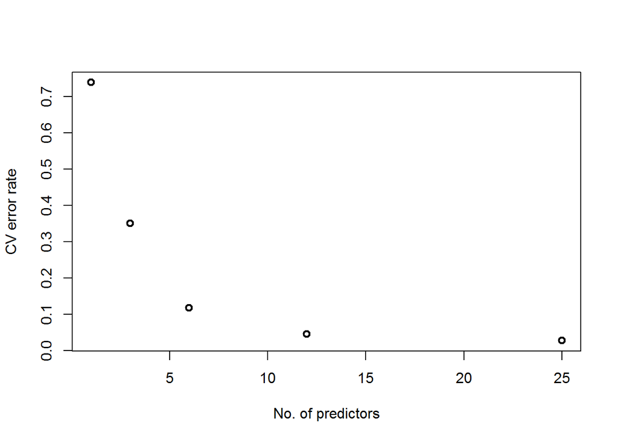

```r
cval <- rfcv(trainPC,training[,53])
with(cval,plot(n.var,error.cv,lwd=2, xlab="No. of predictors", ylab="CV error rate"))
```

From the error rate plot, we see that the more the predictors, the lower the CV error rate. We need include all 25 Principal Components.

The out of sample error rate estimated by "cval$error.cv" is 3% for 25 PCs.

```r
modelfit<-train(training$classe~.,data=trainPC,method="rf")
```

Next we do validation using the testPC, the principal components of the training set partitioned for testing.

```r
confusionMatrix(predict(modelfit,testPC),testing$classe)
```

```
## Confusion Matrix and Statistics
##
##           Reference
## Prediction    A    B    C    D    E
##          A 1386   14    3    2    1
##          B    4  919   17    0    5
##          C    4   14  825   25    6
##          D    1    0    8  776    4
##          E    0    2    2    1  885
##
## Overall Statistics
##
##                Accuracy : 0.977
##                  95% CI : (0.9724, 0.981)
##     No Information Rate : 0.2845
##     P-Value [Acc > NIR] : < 2.2e-16
##
##                   Kappa : 0.9708
##  Mcnemar's Test P-Value : NA
##
## Statistics by Class:
##
##                      Class: A Class: B Class: C Class: D Class: E
## Sensitivity            0.9935   0.9684   0.9649   0.9652   0.9822
## Specificity            0.9943   0.9934   0.9879   0.9968   0.9988
## Pos Pred Value         0.9858   0.9725   0.9439   0.9835   0.9944
## Neg Pred Value         0.9974   0.9924   0.9926   0.9932   0.9960
## Prevalence             0.2845   0.1935   0.1743   0.1639   0.1837
## Detection Rate         0.2826   0.1874   0.1682   0.1582   0.1805
## Detection Prevalence   0.2867   0.1927   0.1782   0.1609   0.1815
## Balanced Accuracy      0.9939   0.9809   0.9764   0.9810   0.9905
```

It is seen that the out of sample accuracy is ~98%.  
Lastly, we do prediction for the final test data for submission.

```r
finaltestdataPC<- predict(preProc,finaltestdata[,-53])
answer<-predict(modelfit,finaltestdataPC)
```

For purpose of submission, the text files are created.

```r
pml_write_files = function(x){
  n = length(x)
  for(i in 1:n){
    filename = paste0("problem_id_",i,".txt")
    write.table(x[i],file=filename,quote=FALSE,row.names=FALSE,col.names=FALSE)
  }
}
pml_write_files(answer)
```

As expected the accuracy of this algorithm is close ~90% as evaluated by the 20 samples.

## Summary

Principal components analysis was used to reduce predictors to ~25 and random forest was used as the classification prediction model. The accuracy is >90%. And this author was able to get a score of 18/20 in the 1st round submission based on the output of the model.